# Project 2: Data Analysis Report- [WeRateDogs]

- Introduction
- Analysing data
- Insights
- Conclusion

## Introduction

The goal of the analysis is to get atleast 3 insights and 1 visualization from the dataset. We had used the merged dataset which comprised of the enhanced twitter archived data, the image prediction data and the tweet json datasets. A copy of the merged dataset was made and and stored as Twitter_df which was used for the analysis. The Twitter_df dataset contains 1953 rows and 12 columns. Some of the columns includes, ratings, favourite counts, retweet counts, dogs breed, the image url for each dogs, the tweet id, etc.

## Accessing

We commenced the analysis by making some exploration of the dataset. We next proceed to visualize the distribution of the rating column of the dataset. We also explore the Dogs breed columns, the aim was to see the most common breed in the dataset. We also investigated the relationship between the number of retweets and the number of favourites counts. We plot to see the correlation between the two variables. We also investigated the dogs breed with respect to the favourite counts. This allowed us to see the dog breeds with the most favourite counts. We concluded by visualizing the most popular dog breed with the most favourite and most rated counts.

## Insight

1. The first insight we noticed in the analysis was in the distribution of the ratings as can be seen in the figure 1 below. We observed that ratings of 10, 11, 12 and 13 are common in the dataset. We can say that people who are rating a quite excited about what they see.

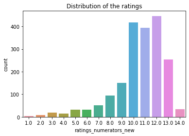

Figure 1: Distrubution of the Dogs ratings.

1. From the analysis of the dog breeds, we observed that the Golden retriever breed appeared to be most commonly predicted breed in the dataset as shown in the figure 2 below. This is followed by the Labrador retriever. To support our analysis, according to wikipedia, the Golden retriever is a commonly kept pet dogs among the western countries.

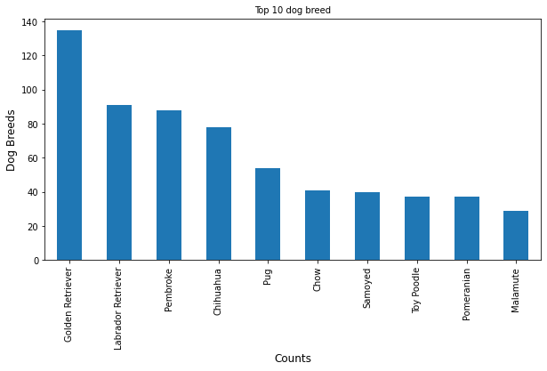

Figure 2: Dog breeds frequency

1. Next we investigate the relationship between the numbers retweet and the favourite counts. The investigate shows that there is a positive correlation between the two variables. This can be observed in the figure 3 below.

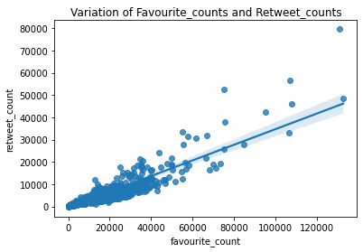

Figure 3: Correlation plot of retweet counts and favourite count.

### Further Visualisations

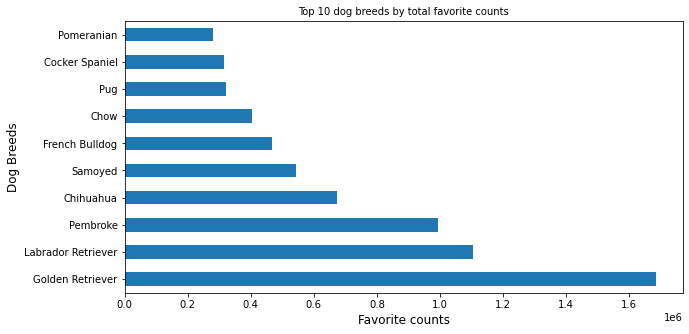

Figure 4: First 10 dogs with the most favourite counts

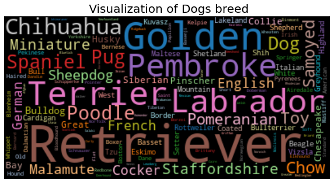

Figure 5: Word cloud display of the dog breeds in the dataset.

## Conclusion

We have investigated the WeRateDogs twitter dataset. We started from the data wrangling phase where we gathered, access and cleaned data both visually and programmatically. We move to make a brief analysis of the data. Our observations shows that there are more generally positive ratings of dogs. The Golden retriever appeared to be the most popular dog breed in the dataset and the it is also clear that the more retweet a dog post gets, the more the favourite counts.